# Whole Genome Sequencing of *Botrytis cinerea* Isolates

Ido Bar

18 July 2017

# Experimental Design

DNA was extracted from 20 strains of *Botrytis cinerea* and 2 *Botrytis fabae* isolates and sent for Whole-Genome-Sequencing (WGS) at the Australian Genome Research Facility (AGRF, Melbourne) on a single flowcell an Illumina NovaSeq, producing 150 bp short paired-end reads (run name CAGRF20074).  
Details of the sequenced isolates is provided in (Table 1).

```r
# datatable(as.data.frame(samples_table), caption=tbls("samples"))
kable(isolate_table) %>%
  kable_styling(bootstrap_options = c("striped", "hover", "condensed", "responsive"),
                full_width = F, position = "left") %>%
  column_spec(3, italic=TRUE) %>%
  column_spec(1, bold = T)
```

| Sample_ID | Sample_name | Species |
| --- | --- | --- |
| 1 | 214/99 | Botrytis cinerea |
| 2 | B589-2 | Botrytis cinerea |
| 3 | B757-4 | Botrytis cinerea |
| 4 | 9053 | Botrytis cinerea |
| 5 | 10418 | Botrytis cinerea |
| 6 | Kingsford2 | Botrytis cinerea |
| 7 | 9136 | Botrytis cinerea |
| 8 | 8748 | Botrytis cinerea |
| 9 | 8880 | Botrytis cinerea |
| 10 | 9345 | Botrytis cinerea |
| 11 | 9564 | Botrytis cinerea |
| 12 | 9653 | Botrytis cinerea |
| 13 | 10412 | Botrytis cinerea |
| 14 | TR9815 | Botrytis cinerea |
| 15 | BGM_Pod_S.H-3 | Botrytis cinerea |
| 16 | 8762 | Botrytis cinerea |
| 17 | 8763 | Botrytis cinerea |
| 18 | 9550 | Botrytis cinerea |
| 19 | B402 | Botrytis cinerea |
| 20 | B775-1 | Botrytis cinerea |
| 21 | B16-1 | Botrytis fabae |
| 22 | B16-2 | Botrytis fabae |

# Aims

- Verify conservation of the molecular probes regions within *B. cinerea* isolates
- Confirm molecular probes specificity in comparison to *B. fabae* isolates

# Analysis Pipeline

## General overview:

1. Data pre-processing:
   1. Quality check
   2. Adaptor trimming
   3. Post-trim quality check
2. Reads deduplication
3. Mapping reads to a reference genome (keep unmapped)
4. Alignment visualisation in probe regions

## Methods

### Data pre-processing

Install needed software in a `conda` environment on Gowonda2.

```bash
# install sambamba (need to fix internet connection to gowonda2 - use patched netcheck in ~/bin)
~/bin/netcheck
conda install -c bioconda sambamba htslib samtools bcftools snpsift snpeff multiqc fastqc dnapi igvtools qualimap bbmap gatk picard bowtie2 samblaster freebayes jellyfish bbmap
conda install -c biobuilds igv
# Clean extra space
conda clean -y --all
# Install pdfx to parse the report and download the files, see https://stackoverflow.com/a/33173484
easy_install -U pdfx
```

#### Adaptor Trimming

Adaptors needed to be removed, as well as very low quality bases/reads, so trimming was performed with BBduk (from BBMap v38.34). See official download page on [SourceForge](https://sourceforge.net/projects/bbmap/), [user guide](http://jgi.doe.gov/data-and-tools/bbtools/bb-tools-user-guide/bbduk-guide/) and [SEQanswers thread](http://seqanswers.com/forums/showthread.php?t=42776).

### Mapping to the reference genome (using Bowtie2)

#### AGRF batch

Download all the raw `.fastq.gz` files from AGRF.

```bash
mkdir -p ~/data/Marzia/B_cinerea_WGS
# Retrieve all files from AGRF
rsync -avh -e ssh IdoBar1@agrf-data.agrf.org.au:files/AGRF_CAGRF20074_HFLHKDRXX  ~/data/Marzia/B_cinerea_WGS/
# verify that ll files were downloaded
cd ~/data/Marzia/B_cinerea_WGS/AGRF_CAGRF20074_HFLHKDRXX
md5sum -c checksums.md5
```

```bash
# Prepare the BBduk commands
DATE=`date +%d_%m_%Y`
BATCH=AGRF
RUN="${BATCH}_BT2_process_${DATE}" # day of run was 02_02_2019
mkdir ${RUN}
cd !$
GENOME="$HOME/scratch/data/reference_genomes/Fungal_genomes/B.cinerea/GCA_000143535.4_ASM14353v4"
READ_LENGTH=150
NCORES=12
# PLOIDY=1
# LANES=$( ls -1 ../*.fastq.gz | egrep -o "_L[0-9]+?_" | sort | uniq | wc -l )
RGPL=NovaSeq
RGPU=HFLHKDRXX
RGCN=AGRF

# Rename the read files from each lane (and remove barcode and flowcell information)
ln -s ../*.fastq.gz ./
my_rename -v "s/_${RGPU}_[ACGT-]*_L002//" *.fastq.gz

# Prepare PBS script
echo '#!/bin/bash -v
#PBS -V
#PBS -l' "select=1:ncpus=$NCORES:mem=48GB,walltime=1:30:00

cd \$PBS_O_WORKDIR
gawk -v ARRAY_IND=\$PBS_ARRAY_INDEX 'NR==ARRAY_IND' \${CMDS_FILE} | bash" > ${RUN}.pbspro

# Build bowtie2 index
BT2_IDX_ID=$( echo "cd $( pwd ) ; bowtie2-build ${GENOME}_genomic.fna ${GENOME}" | qsub -V -l select=1:ncpus=12:mem=4GB,walltime=1:00:00  -N bt2-build ) # 5248661.pbsserver
BT2_IDX_ID=$( echo $BT2_IDX_ID | egrep -o "[0-9]{7}" )

# Perform adapter trimming, mapping, deduplication, add RG, sort and index
find ./ -maxdepth 1 -name "*_R1.fastq.gz" | sort | gawk -F"\t" -v bbmap_dir=$BBMAP_DIR -v genome=$GENOME -v RGPL=$RGPL -v RGPU=$RGPU -v RGCN=$RGCN -v ncores=$NCORES 'BEGIN{command=sprintf("bbduk.sh -Xmx1g ref=%s/resources/adapters.fa ktrim=r k=23 mink=11 hdist=1 qtrim=rl trimq=10 tpe tbo int minlen=30 ziplevel=9 ow", bbmap_dir)};{n=split($1,a,"/"); infile=gensub("_R1\\.", "_R#.", "1", $1); basename=gensub(/(.+)_R1.fastq.gz/, "\\1", "1", a[n]) ; printf("cd $PBS_O_WORKDIR; %s in=%s out=trimmed_%s_R#.fastq.gz stats=%s.stats ow && bowtie2 --very-sensitive -p %s -x %s -1 trimmed_%s_R1.fastq.gz -2 trimmed_%s_R2.fastq.gz --un-conc-gz %s_unmapped.fq.gz --no-unal | samblaster | picard AddOrReplaceReadGroups I=/dev/stdin O=%s_BT2_Bc_B05.10.dedup.rg.csorted.bam SM=%s ID=%s_%s LB=%s PL=%s PU=%s CN=%s CREATE_INDEX=true  SO=coordinate \n", command, infile, basename, basename, ncores, genome, basename, basename, basename, basename, basename, basename, NR, basename, RGPL,RGPU, RGCN)}' > ${RUN}.bash

# Run on parallel nodes (faster and preferred)

# Run the commands
JOB_NAME=${RUN}
JOBS_NUM=`wc -l ${RUN}.bash | gawk '{print $1}'`
BT2_ID=$( qsub -J1-$JOBS_NUM -N ${JOB_NAME:0:11} -vCMDS_FILE=${RUN}.bash  ${RUN}.pbspro )
BT2_ID=$( echo $BT2_ID | egrep -o "[0-9]{7}"  )
# record the array ID: 5379814[] AGRF batch on Gowonda

# Run FastQC on the output files
QC_JOB=${BATCH}_trim_qc_"${DATE}"
QC_JOB_ID=$( echo "cd $( pwd ) ; mkdir $QC_JOB; fastqc -t 12 -o $QC_JOB trimmed_*.fastq.gz" | qsub -V -l select=1:ncpus=12:mem=4GB,walltime=1:00:00  -N trim_qc -W depend=afterok:$BT2_ID[] ) # 5379815.pbsserv
QC_JOB_ID=$( echo $QC_JOB_ID | egrep -o "[0-9]{7}" )

# Run qualimap on bam files (files need to be sorted)
QUALIMAP_JOB="${BATCH}_qualimap_${DATE}"
# copy to the parent folder file describing the sample names (sample_info.txt)
QUALIMAP_JOB_ID=$( echo "cd $( pwd ) ; unset DISPLAY ; gawk -F'\t' 'NR>1{sample_name=gsub(/ /, \"_\", \$3); printf \"%s\t%s_BT2_Bc_B05.10.dedup.rg.csorted.bam\n\", \$3, \$1}' ../sample_info.txt > $QUALIMAP_JOB.samples ; qualimap multi-bamqc -r -d $QUALIMAP_JOB.samples -outformat PDF:HTML -outdir $QUALIMAP_JOB -outfile $QUALIMAP_JOB.pdf" | qsub -V -l select=1:ncpus=12:mem=8GB,walltime=3:00:00 -N ${QUALIMAP_JOB:0:11} -W depend=afterok:$BT2_ID[] ) # 5379816.pbsserv
QUALIMAP_JOB_ID=$( echo $QUALIMAP_JOB_ID | egrep -o "[0-9]{7}" )

# multiqc report
MULTIQC_JOB="${BATCH}_BT2_qc_${DATE}"
echo "cd $( pwd ) ; multiqc -i $MULTIQC_JOB -o $MULTIQC_JOB ." | qsub -V -l select=1:ncpus=12:mem=4GB,walltime=1:00:00 -N ${MULTIQC_JOB:0:11} -W depend=afterok:$QUALIMAP_JOB_ID:$QC_JOB_ID # 5379817.pbsserver

# collect mapping stats
cat *.e$BT2_ID.* > ${RUN}.log
egrep "Created read-group|overall alignment rate" ${RUN}.log | gawk 'BEGIN{printf "sample_id\tmapping_rate\n"} NR%2==1{match($0, /SM=(.+?)$/, a); printf a[1]} NR%2==0{printf "\t%s\n",$1}'   > ${RUN}.stats.tmp

# collect trimming stats

egrep "Input:|Result:" ${RUN}.log | gawk -v OFS="\t" 'BEGIN{printf "input_reads\tinput_bases\tpost_trim_reads\tpost_trim_bases\n"}NR%2==1{printf "%s\t%s\t",$2,$4}NR%2==0{print $2,$5}' | paste ${RUN}.stats.tmp - >  ${RUN}.stats

# merge bams
IGNORE_SAMS='13_BT2|9_BT2|4_BT2|7_BT2|21_BT2|22_BT2'

# merge to a single file
BAMS=$( ls -1 ./*.csorted.bam | egrep -v $IGNORE_SAMS | gawk -v ORS=" " '{print $1}' )
FINAL_MERGE=$( echo "cd $( pwd ) ; sambamba merge -t $NCORES -l 8 B_cinerea.all.csorted.combined.bam $BAMS " | qsub -V -l select=1:ncpus=${NCORES}:mem=96GB,walltime=5:00:00 -N Final_merge )
#FINAL_MERGE=$( echo "cd $( pwd ) ; picard MergeSamFiles USE_THREADING=true SO=coordinate $BAMS O=all.csorted.combined.bam" | qsub -V -l select=1:ncpus=${NCORES}:mem=96GB,walltime=5:00:00 -N Final_merge ) # 5248672.pbsserver
FINAL_MERGE_ID=$( echo $FINAL_MERGE | egrep -o "[0-9]{7}")

# save read groups to file
sambamba view -H B_cinerea.all.csorted.combined.bam | grep "^@RG" > B_cinerea_all_read_groups.txt

# merge bams from Fabae isolates to a single file
FABAE_BAMS=$( ls -1 ./*.csorted.bam | egrep '21_BT2|22_BT2' | gawk -v ORS=" " '{print $1}' )
FABAE_MERGE=$( echo "cd $( pwd ) ; sambamba merge -t $NCORES -l 8 B_fabae.csorted.combined.bam $FABAE_BAMS " | qsub -V -l select=1:ncpus=${NCORES}:mem=96GB,walltime=5:00:00 -N Fabae_merge )
#FINAL_MERGE=$( echo "cd $( pwd ) ; picard MergeSamFiles USE_THREADING=true SO=coordinate $BAMS O=all.csorted.combined.bam" | qsub -V -l select=1:ncpus=${NCORES}:mem=96GB,walltime=5:00:00 -N Final_merge ) # 5248672.pbsserver
FABAE_MERGE_ID=$( echo $FABAE_MERGE | egrep -o "[0-9]{7}")

# find and remove empty files
find . -size 0 -exec rm {} +

# Check that all jobs finished successfuly
find . -regextype posix-egrep -regex '\./.*\.e[0-9]{7}.*' | xargs grep "ExitStatus" #  *m.e$JOB_ID.*
# Done!
```

#### Contaminations in samples

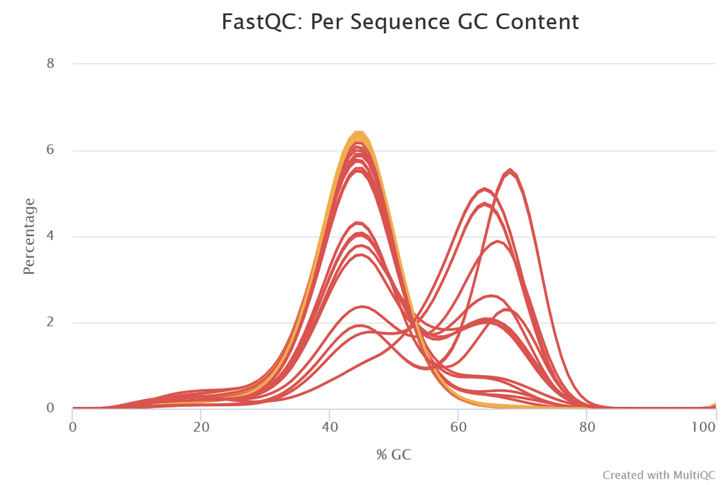

Figure 1: GC content per sample in WGS reads.

```r
datatable(as.data.frame(qualimap_results %>% mutate_if(is.numeric, ~round(., 2))), caption=tbls("mapping_rates")) %>% #,
          # options = list(dom = 'tf', pageLength = 40)) %>%
  formatStyle("Coverage", target = "row",
  backgroundColor = styleInterval(c(20,40), c('#ef3125', '#feed95', NA))
)
```

|  | Sample_ID | Isolate | GC_percentage | Mapping_quality_mean | Mapping_rate | Coverage | Mapping_tool | Species |
| --- | --- | --- | --- | --- | --- | --- | --- | --- |
| 1 | 1 | 214/99 | 42.97 | 38.98 | 0.91 | 114.5 | Bowtie2 (v2.3.5) | Botrytis cinerea |
| 2 | 2 | B589-2 | 43.07 | 38.99 | 0.81 | 112.11 | Bowtie2 (v2.3.5) | Botrytis cinerea |
| 3 | 3 | B757-4 | 42.87 | 39.14 | 0.94 | 148.42 | Bowtie2 (v2.3.5) | Botrytis cinerea |
| 4 | 4 | 9053 | 43.07 | 39.35 | 0.21 | 39.4 | Bowtie2 (v2.3.5) | Botrytis cinerea |
| 5 | 5 | 10418 | 42.57 | 39.22 | 0.59 | 84.19 | Bowtie2 (v2.3.5) | Botrytis cinerea |
| 6 | 6 | Kingsford2 | 43.27 | 38.92 | 0.96 | 127.95 | Bowtie2 (v2.3.5) | Botrytis cinerea |
| 7 | 7 | 9136 | 42.69 | 39.57 | 0.07 | 12.75 | Bowtie2 (v2.3.5) | Botrytis cinerea |
| 8 | 8 | 8748 | 42.78 | 38.36 | 0.64 | 88.67 | Bowtie2 (v2.3.5) | Botrytis cinerea |
| 9 | 9 | 8880 | 42.85 | 38.13 | 0.27 | 46.13 | Bowtie2 (v2.3.5) | Botrytis cinerea |
| 10 | 10 | 9345 | 43.24 | 38.03 | 0.86 | 132.39 | Bowtie2 (v2.3.5) | Botrytis cinerea |

[output cut: 12 more lines]

```r
# pander(as.data.frame(qualimap_results), caption=tbls("mapping_rates"), justify="left")

# datatable(as.data.frame(mapping_stats), caption = tbls("mapping_rates"), # , width=10
#           style="default", rownames = FALSE, autoHideNavigation=TRUE) %>%
#   formatPercentage('Mapping_rate', 2) %>% #formatStyle('Isolate',
#   formatStyle('Mapping_rate',
#     color = styleInterval(c(0.05, 0.5), c('yellow', 'blue', 'black')),
#     backgroundColor = styleInterval(c(0.05, 0.5), c('red', 'yellow',NA))
#   )
```

#### Assess genome size and ploidy

The sequencing data of 4 isolates with sufficient coverage and no apparent contamination were analyzed for their k-mer content (coverage and distribution) to estimate the genome size and ploidy of the genome.  
k-mer counting and genome ploidy and size estimation were performed with `kmercountexact.sh` (from BBMap v38.34, using the odd numbers in the range of 21-37 as kmers, i.e 21, 23, 25..35, 37 (see [SeqAnsewes thread](http://seqanswers.com/forums/showthread.php?t=64086)).  
Similar analysis can be performed by Jellyfish (see [tutorial](http://koke.asrc.kanazawa-u.ac.jp/HOWTO/kmer-genomesize.html))

```bash
DATE=`date +%d_%m_%Y`
RUN=kmer_analysis_${DATE} # day of run was 02_02_2019
mkdir ${RUN}
cd !$

# Prepare PBS script
echo '#!/bin/bash -x
#PBS -V
#PBS -l select=1:ncpus=12:mem=48GB,walltime=00:30:00

cd $PBS_O_WORKDIR
gawk -v ARRAY_IND=$PBS_ARRAY_INDEX'" 'NR==ARRAY_IND' \${CMDS_FILE} | bash" > ${RUN}.pbspro

# run BB kmercount
SAMPLES=($(seq 17 20))
for SAMPLE in "${SAMPLES[@]}"; do
  ln -s /export/home/s2978925/data/Marzia/B_cinerea_WGS/AGRF_CAGRF20074_HFLHKDRXX/AGRF_BT2_process_19_09_2019/trimmed_${SAMPLE}*.fastq.gz ./
  seq 21 2 37 | parallel --dry-run kmercountexact.sh k={} in=trimmed_${SAMPLE}_R1.fastq.gz in2=trimmed_${SAMPLE}_R2.fastq.gz khist=${SAMPLE}_khist_k{}.txt peaks=${SAMPLE}_peaks_k{}.txt > ${SAMPLE}_${RUN}.bash
  # Run the commands
  JOB_NAME=bb_kmer
  JOBS_NUM=$( wc -l ${SAMPLE}_${RUN}.bash | gawk '{print $1}' )
  qsub -J1-$JOBS_NUM -N ${JOB_NAME:0:11} -vCMDS_FILE=${SAMPLE}_${RUN}.bash ${RUN}.pbspro # 5374038[].pbsserver
done

# find and remove empty files
find . -size 0 -exec rm {} +
rm *.tmp

# Check that all jobs finished successfuly
find . -regextype posix-egrep -regex '\./.*\.e[0-9]{7}.*' | xargs grep "ExitStatus" #  *m.e$JOB_ID.*

# aggregate data from all output files (and transpose)

grep "^#" ${SAMPLES[0]}_peaks_k21.txt  | head -n -1 | sed "s/#//" | cat <( printf "sample\t%s\n" $SAMPLE) - | cut -f1 | paste -s > kmer_peaks_summary.txt
parallel "grep "^#" {1}_peaks_k{2}.txt | head -n -1 | sed "s/#//" | cat  <(echo {1}) - | cut -f2 | paste -s" ::: ${SAMPLES[@]} ::: $(seq 21 2 37) >> kmer_peaks_summary.txt
# for SAMPLE in "${SAMPLES[@]}"; do
#  ls -1 ${SAMPLE}_peaks*.txt | parallel "grep "^#" {} | head -n -1 | sed "s/#//" | cat  <(echo $SAMPLE) - | cut -f2 | paste -s" >> kmer_peaks_summary.tst
#  done

# do the same for the hist data (maybe with gawk)
gawk 'NR==1{printf "Sample\tkmer\t%s\n", $0}' ${SAMPLES[0]}_khist_k21.txt | sed "s/#//"  >  khist_summary.txt
parallel "tail -n +2 {1}_khist_k{2}.txt | gawk '{print \"{1}\t{2}\t\"\$0}'" ::: ${SAMPLES[@]} ::: $(seq 21 2 37) >> khist_summary.txt

# Done!
```

The selected samples were B402, B775-1, 9550, 8763, see coverage details in Table 2. The resulting kmer count data for all samples and kmers was aggregated into tables and summarised in the following plots

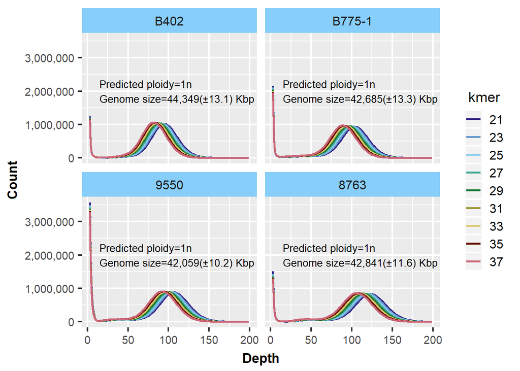

Figure 2: K-mer distribution in 4 selected isolates and the predicted genome size and ploidy.

#### Extract primer regions

The alignment files of the samples (excluding the ones that did not pass QC) were combined into a single file that was used cropped to the primer regions to focus and vsualise the alignments.

```bash
# save read groups to file
sambamba view -H all.csorted.combined.bam | grep "^@RG" > all_read_groups.txt
# BAM_FILES=$( ls -1 $MERGE_JOB/*.csorted.bam | gawk -vORS=" " '1' )
# calculate coverage
CALC_COV=$( echo "cd $( pwd ) ;  sambamba depth base --combined all.csorted.combined.bam | cut -f 1-3 | tail -n +2 | coverage_to_regions.py $GENOME.fasta.fai 500 > targets.regions " | qsub -V -l select=1:ncpus=${NCORES}:mem=96GB,walltime=5:00:00 -N Calc_cov -W depend=afterok:$FINAL_MERGE_ID ) # 5248672.pbsserver
CALC_COV_ID=$( echo $CALC_COV | egrep -o "[0-9]{7}")
# /export/home/s2978925/.pyenv/versions/miniconda2-latest/bin/bamtools coverage -in
# prepare Freebayes commands
FB=freebayes_${DATE}
FB_CMDS=$( echo "cd $( pwd ) ; cat targets.regions | parallel --dry-run -k \"freebayes -p $PLOIDY -f $GENOME.fasta all.csorted.combined.bam --region {}\" > $FB.cmds" | qsub -V -l select=1:ncpus=${NCORES}:mem=96GB,walltime=5:00:00 -N FB_cmds -W depend=afterok:$CALC_COV_ID ) # 5248672.pbsserver
# get job_id
FB_CMDS_ID=$( echo $FB_CMDS | egrep -o "[0-9]{7}")

# Send freebayes jobs to the cluster
# Prepare PBS script
echo '#!'"/bin/bash -v
#PBS -V
#PBS -l select=1:ncpus=${NCORES}:mem=64GB,walltime=20:00:00
"'
cd $PBS_O_WORKDIR
ARRAYID=$( echo $PBS_ARRAY_ID | egrep -o "[0-9]{7}" )
gawk -v ARRAY_IND=$PBS_ARRAY_INDEX'" 'NR>(${NCORES}*3*(ARRAY_IND-1)) && NR<=(ARRAY_IND*${NCORES}*3)' \${CMDS_FILE} | parallel -k -j ${NCORES} --joblog"' ${CMDS_FILE}.p$ARRAYID.$PBS_ARRAY_INDEX' > freebayes.pbspro

NCMDS=$( wc -l $FB.cmds | gawk '{print $1}')
NJOBS=$(( NCMDS/NCORES/3 + 1  ))
FB_JOB=$( qsub -J1-$NJOBS -N ${FB:0:11} -W depend=afterok:$FB_CMDS_ID -vCMDS_FILE=$FB.cmds freebayes.pbspro )
# 5270639[1-4] completed successfully (the rest needed more processing time)
FB_JOB_ID=$( echo $FB_JOB | egrep -o "[0-9]{7}")

CONCAT_FB=$( echo "cd $( pwd ) ; cat *.o$FB_JOB_ID* | vcffirstheader | vcfstreamsort -w 1000 | vcfuniq > A_rabiei_2018_isolates_haplo.fb.vcf" | qsub -V -l select=1:ncpus=${NCORES}:mem=96GB,walltime=10:00:00 -N FB_vcf -W depend=afterok:$FB_JOB_ID[] -m e -M i.bar@griffith.edu.au)
CONCAT_FB_ID=$( echo $CONCAT_FB | egrep -o "[0-9]{7}" )

# check for success/failure of FB commands
tail -n +2 $FB.cmds.p*.* | cut -f7,9 | gawk '$1==1' > $FB.failed.cmds
tail -n +2 $FB.cmds.p*.* | cut -f7,9 | gawk '$1==0' > $FB.successful.cmds

# Produce vcf stats
SAMPLES=$( cut -f6 all_read_groups.txt | gawk -F":" -vORS="," '{print $2}' | sed 's/,$//' )
FB_STATS=$( echo "cd $( pwd ) ; mkdir ${FB}_stats; bcftools stats -F $GENOME.fasta -s $SAMPLES A_rabiei_2018_isolates_haplo.fb.vcf > ${FB}_stats/A_rabiei_2018_isolates_haplo.fb.vcf.stats; plot-vcfstats -p ${FB}_stats ${FB}_stats/A_rabiei_2018_isolates_haplo.fb.vcf.stats" | qsub -V -l select=1:ncpus=${NCORES}:mem=96GB,walltime=10:00:00 -N FB_vcfstats -W depend=afterok:$CONCAT_FB_ID -m e -M i.bar@griffith.edu.au)
FB_STATS_ID=$( echo $FB_STATS | egrep -o "[0-9]{7}" )

# find and remove empty files
find . -size 0 -exec rm {} +

# check jobs completion
find . -regextype posix-egrep -regex '\./.*\.e[0-9]{7}.*' | xargs grep "ExitStatus"
```

## Appendix 1. Useful resources

- Whole-Genome Comparison of *Aspergillus fumigatus* Strains Serially Isolated from Patients with Aspergillosis. (Hagiwara *et al.* 2014):

> **Sequence analysis:** The Illumina data sets were trimmed using fastq-mcf in ea-utils (version 1.1.2-484), i.e., sequencing adapters and sequences with low quality scores (Phred score [Q], <30) were removed (24). The data sets were mapped to the genome sequence of the *A. fumigatus* genome reference strain Af293 (29,420,142 bp, genome version s03-m04-r03) (25, 26) using Bowtie 2 (version 2.0.0-beta7) with the very sensitive option in end-to-end mode (27). Duplicated reads were removed using Picard (version 1.112) (http://picard.sourceforge.net). The programs mpileup and bcftools from SAMtools (version 0.1.19-44428cd) were used to perform further quality controls. In mpileup, the -q20 argument was used to trim reads with low-quality mapping, whereas the argument -q30 was used to trim low-quality bases at the 3’ end (28). The bcftools setting was set to -c in order to call variants using Bayesian inference. Consensus and single nucleotide polymorphisms (SNPs) were excluded if they did not meet a minimum coverage of 5x or if the variant was present in <90% of the base calls (29, 30). The genotype field in the variant call format (VCF) files indicates homozygote and heterozygote probabilities as Phred-scaled likelihoods. SNPs were excluded if they were called as heterozygous genotypes using SAMtools. The mapping results were visualized in the Integrative Genomics Viewer (version 2.3.3) (31, 32). The reference genome data included information on open reading frames and annotations, from which the SNPs were designated non-synonymous or synonymous.  
> Single nucleotide mutations were confirmed by Sanger sequencing. Regions of approximately 400 bp that contained a mutation were amplified with appropriately designed primer pairs and then sequenced. The primer sequences are listed in Table S1 in the supplemental material, which were named as follows. For verification of the SNPs in strains from patient I or patient II, PaI or PaII was added to the primer name, respectively. For non-synonymous SNPs, synonymous SNPs, or SNPs in a non-coding region, (NS, Syno, NonC) was added to the primer name, respectively.  
> **Analysis of unmapped reads:** *De novo* assembly of the unmapped reads was conducted using the Newbler assembler 2.9 (Roche), with default parameters. The contigs were selected based on size/depth criteria: those of <500 bp and/or with a depth of <30x coverage were removed. To investigate whether unique genome sequences were present in strains isolated from the same patient, the unmapped reads of each strain were mapped to the contigs generated from all the strains in the same patient by the Bowtie 2 software. The coverage of the mapped regions was then evaluated. Gene predictions were performed using the gene prediction tool AUGUSTUS (version 2.5.5), with a training set of *A. fumigatus* (33). The parameters of AUGUSTUS were -species = aspergillus_fumigatus, -strand = both, -genemodel = partial, -singlestrand = false, -protein = on, -introns = on, -start = on, -stop = on, -cds = on, and -gff3 = on. To compare all the predicted genes with *Aspergillus* genes, consisting of 244,811 genes available on AspGD (34), a reciprocal BLAST best hit approach was performed by BLASTp (35), with an E value of 1.0e<sup>-4</sup>. All BLASTp results were filtered based on a BLASTp identity of $\ge 80$% and an aligned length coverage of $\ge 80$%.

## General information

This document was last updated at 2019-09-25 10:16:45 using R Markdown (built with R version 3.5.1 (2018-07-02)). Markdown is a simple formatting syntax for authoring HTML, PDF, and MS Word documents. It is especially powerful at authoring documents and reports which include code and can execute code and use the results in the output. For more details on using R Markdown see http://rmarkdown.rstudio.com and [Rmarkdown cheatsheet](https://www.rstudio.com/wp-content/uploads/2016/03/rmarkdown-cheatsheet-2.0.pdf).

## Bibliography

Ewels P, Magnusson M, Lundin S, Käller M (2016) MultiQC: Summarize analysis results for multiple tools and samples in a single report. Bioinformatics 32:3047–3048. doi: 10.1093/bioinformatics/btw354

Faust GG, Hall IM (2014) SAMBLASTER: Fast duplicate marking and structural variant read extraction. bioinformatics 30:2503–2505. doi: 10.1093/bioinformatics/btu314

Haas BJ, Zeng Q, Pearson MD, et al. (2011) Approaches to Fungal Genome Annotation. Mycology 2:118–141. doi: 10.1080/21501203.2011.606851

Hagiwara D, Takahashi H, Watanabe A, et al. (2014) Whole-Genome Comparison of *Aspergillus* *Fumigatus* Strains Serially Isolated from Patients with Aspergillosis. J Clin Microbiol 52:4202–4209. doi: 10.1128/JCM.01105-14

Hittalmani S, Mahesh HB, Mahadevaiah C, Prasannakumar MK (2016) De novo genome assembly and annotation of rice sheath rot fungus *Sarocladium* oryzae reveals genes involved in Helvolic acid and Cerulenin biosynthesis pathways. BMC Genomics 17:271. doi: 10.1186/s12864-016-2599-0